# Game, Set, Data: Uncovering Insights from Women’s Tennis Tournaments

ali güzel

2024-07-14

In this project, we analyze a dataset containing information about women’s tennis matches between 2015 and 2017. We will use data manipulation and visualization techniques to extract meaningful insights from the dataset. This analysis involves creating new variables, summarizing data, and visualizing results. Let’s walk through the process step-by-step.

We begin by loading the dataset and necessary libraries. The dataset tennis_data.rda contains comprehensive information about various tennis tournaments, matches, and players. For more information, you can check *tennis_data_explanation.txt*

The `tidyverse` package is a collection of R packages designed for data science. It includes `dplyr`, `ggplot2`, `tidyr`, `readr`, `purrr`, and `tibble`, among others. These packages work together to make data manipulation, visualization, and programming easier.

The `lubridate` package makes it easier to work with dates and times in R. It provides functions for parsing, manipulating, and performing arithmetic with date-time objects.

```r
load(file.choose())
library(tidyverse)
library(lubridate)
```

Before start to analyze, lets take a look to the data:

```r
print(tennis_data,width = Inf,n=6)
```

```
## # A tibble: 130,750 × 13
##   tourney_id              tourney_name tourney_start_date surface match_num
##   <chr>                   <chr>        <date>             <chr>   <chr>
## 1 2015-W-C10-ALG-01A-2015 W10 Tlemcen  2015-09-14         Clay    10_R16
## 2 2015-W-C10-ALG-01A-2015 W10 Tlemcen  2015-09-14         Clay    10_R16
## 3 2015-W-C10-ALG-01A-2015 W10 Tlemcen  2015-09-14         Clay    11_R16
## 4 2015-W-C10-ALG-01A-2015 W10 Tlemcen  2015-09-14         Clay    11_R16
## 5 2015-W-C10-ALG-01A-2015 W10 Tlemcen  2015-09-14         Clay    12_R16
## 6 2015-W-C10-ALG-01A-2015 W10 Tlemcen  2015-09-14         Clay    12_R16
##   round score   player_id Full_Name         win_loss player_rank dateofbirth
##   <chr> <chr>   <chr>     <chr>             <chr>    <chr>             <int>
## 1 R16   6-1 6-1 211408    Kerstin Peckl     loser    946            19890902
## 2 R16   6-1 6-1 213972    Ines Ibbou        winner   <NA>           19990105
## 3 R16   6-1 6-0 214867    Hanine Boudjadi   loser    <NA>           19991007
## 4 R16   6-1 6-0 211712    Polina Novoselova winner   1071           19961117
## 5 R16   6-1 6-3 205495    Asha Nanda Kumar  loser    <NA>           19871009
## 6 R16   6-1 6-3 213934    Nora Niedmers     winner   742            19950110
##   country
##   <chr>
## 1 AUT
## 2 ALG
## 3 ALG
## 4 RUS
## 5 IND
## 6 GER
## # ℹ 130,744 more rows
```

First, lets extract the tournament year from the start date and create a new variable tourney_year for further analysis. year function can be used to exctrat from a date variable. Then, we can relocate this new column for better readability:

```r
Q9 = tennis_data %>%
        mutate(tourney_year = year(tourney_start_date)) %>%
        relocate(tourney_year, .after = tourney_start_date)
Q9
```

```
## # A tibble: 130,750 × 14
##    tourney_id     tourney_name tourney_start_date tourney_year surface match_num
##    <chr>          <chr>        <date>                    <dbl> <chr>   <chr>
##  1 2015-W-C10-AL… W10 Tlemcen  2015-09-14                 2015 Clay    10_R16
##  2 2015-W-C10-AL… W10 Tlemcen  2015-09-14                 2015 Clay    10_R16
##  3 2015-W-C10-AL… W10 Tlemcen  2015-09-14                 2015 Clay    11_R16
##  4 2015-W-C10-AL… W10 Tlemcen  2015-09-14                 2015 Clay    11_R16
##  5 2015-W-C10-AL… W10 Tlemcen  2015-09-14                 2015 Clay    12_R16
##  6 2015-W-C10-AL… W10 Tlemcen  2015-09-14                 2015 Clay    12_R16
##  7 2015-W-C10-AL… W10 Tlemcen  2015-09-14                 2015 Clay    13_R16
##  8 2015-W-C10-AL… W10 Tlemcen  2015-09-14                 2015 Clay    13_R16
##  9 2015-W-C10-AL… W10 Tlemcen  2015-09-14                 2015 Clay    14_R16
## 10 2015-W-C10-AL… W10 Tlemcen  2015-09-14                 2015 Clay    14_R16
## # ℹ 130,740 more rows
## # ℹ 8 more variables: round <chr>, score <chr>, player_id <chr>,
## #   Full_Name <chr>, win_loss <chr>, player_rank <chr>, dateofbirth <int>,
## #   country <chr>
```

Next, again for further analysis, we extract the tournament level from the tournament name and create a new variable tourney_level. This column is relocated for clarity:

```r
Q10 = Q9 %>% mutate(tourney_level = str_extract(tourney_name, pattern = "(G|W[0-9]+)")) %>%
          relocate(tourney_level, .after = surface)
Q10
```

```
## # A tibble: 130,750 × 15
##    tourney_id tourney_name tourney_start_date tourney_year surface tourney_level
##    <chr>      <chr>        <date>                    <dbl> <chr>   <chr>
##  1 2015-W-C1… W10 Tlemcen  2015-09-14                 2015 Clay    W10
##  2 2015-W-C1… W10 Tlemcen  2015-09-14                 2015 Clay    W10
##  3 2015-W-C1… W10 Tlemcen  2015-09-14                 2015 Clay    W10
##  4 2015-W-C1… W10 Tlemcen  2015-09-14                 2015 Clay    W10
##  5 2015-W-C1… W10 Tlemcen  2015-09-14                 2015 Clay    W10
##  6 2015-W-C1… W10 Tlemcen  2015-09-14                 2015 Clay    W10
##  7 2015-W-C1… W10 Tlemcen  2015-09-14                 2015 Clay    W10
##  8 2015-W-C1… W10 Tlemcen  2015-09-14                 2015 Clay    W10
##  9 2015-W-C1… W10 Tlemcen  2015-09-14                 2015 Clay    W10
## 10 2015-W-C1… W10 Tlemcen  2015-09-14                 2015 Clay    W10
## # ℹ 130,740 more rows
## # ℹ 9 more variables: match_num <chr>, round <chr>, score <chr>,
## #   player_id <chr>, Full_Name <chr>, win_loss <chr>, player_rank <chr>,
## #   dateofbirth <int>, country <chr>
```

We can see tournnaments with a specific names using filter with grepl function. This function searches for patterns within character vectors and returns a logical vector indicating if the pattern was found. As a result, we’ll see tournaments including ‘Strasbourg’, ‘Roland’, or ‘Madrid’ names in tourney_name variable. Plus, thanks to distinct function, the result only shows only unique ones in terms of selected variables.

```r
Q10 %>% filter(grepl('Strasbourg|Roland|Madrid', tourney_name)) %>%
  select(tourney_name, tourney_level) %>% distinct %>%
  arrange(tourney_name) %>%
  print(n = Inf)
```

```
## # A tibble: 6 × 2
##   tourney_name    tourney_level
##   <chr>           <chr>
## 1 G Roland Garros G
## 2 W10 Madrid      W10
## 3 W1000 Madrid    W1000
## 4 W15 Madrid      W15
## 5 W250 Strasbourg W250
## 6 W500 Madrid     W500
```

Now lets see the winners, losers, and scores of the final games in Grand Slam tournaments for each year. The pivot_wider function reshapes the data to have separate columns for winners and losers.

```r
Q11 = Q10 %>%
  filter(tourney_level == "G" & round == "F") %>%
  pivot_wider(id_cols = c(tourney_name, tourney_year, score), names_from = win_loss, values_from = Full_Name) %>%
  arrange(tourney_name, tourney_year) %>%
  relocate(loser, .after = winner)
Q11
```

```
## # A tibble: 12 × 5
##    tourney_name      tourney_year score          winner           loser
##    <chr>                    <dbl> <chr>          <chr>            <chr>
##  1 G Australian Open         2015 6-3 7-6(5)     Serena Williams  Maria Sharapo…
##  2 G Australian Open         2016 6-4 3-6 6-4    Angelique Kerber Serena Willia…
##  3 G Australian Open         2017 6-4 6-4        Serena Williams  Venus Williams
##  4 G Roland Garros           2015 6-3 6-7(2) 6-2 Serena Williams  Lucie Safarova
##  5 G Roland Garros           2016 7-5 6-4        Garbine Muguruza Serena Willia…
##  6 G Roland Garros           2017 4-6 6-4 6-3    Jelena Ostapenko Simona Halep
##  7 G Us Open                 2015 7-6(4) 6-2     Flavia Pennetta  Roberta Vinci
##  8 G Us Open                 2016 6-3 4-6 6-4    Angelique Kerber Karolina Plis…
##  9 G Us Open                 2017 6-3 6-0        Sloane Stephens  Madison Keys
## 10 G Wimbledon               2015 6-4 6-4        Serena Williams  Garbine Mugur…
## 11 G Wimbledon               2016 7-5 6-3        Serena Williams  Angelique Ker…
## 12 G Wimbledon               2017 7-5 6-0        Garbine Muguruza Venus Williams
```

Now, lets focus on Serena Williams’ career path by filtering all matches she played.

```r
Q12a = Q10 %>% filter(Full_Name == "Serena Williams")
Q12a %>% print(n = 6, width = Inf)
```

```
## # A tibble: 106 × 15
##   tourney_id              tourney_name tourney_start_date tourney_year surface
##   <chr>                   <chr>        <date>                    <dbl> <chr>
## 1 2015-W-INT-SWE-01A-2015 W250 Bastad  2015-07-13                 2015 Clay
## 2 2015-W-INT-SWE-01A-2015 W250 Bastad  2015-07-13                 2015 Clay
## 3 2015-W-P5-CAN-01A-2015  W500 Toronto 2015-08-10                 2015 Hard
## 4 2015-W-P5-CAN-01A-2015  W500 Toronto 2015-08-10                 2015 Hard
## 5 2015-W-P5-CAN-01A-2015  W500 Toronto 2015-08-10                 2015 Hard
## 6 2015-W-P5-CAN-01A-2015  W500 Toronto 2015-08-10                 2015 Hard
##   tourney_level match_num round score       player_id Full_Name       win_loss
##   <chr>         <chr>     <chr> <chr>       <chr>     <chr>           <chr>
## 1 W250          1         R32   6-2 6-1     200033    Serena Williams winner
## 2 W250          17        R16   W/O         200033    Serena Williams loser
## 3 W500          25        R32   2-6 6-3 6-0 200033    Serena Williams winner
## 4 W500          41        R16   6-3 6-2     200033    Serena Williams winner
## 5 W500          49        QF    6-4 6-3     200033    Serena Williams winner
## 6 W500          53        SF    3-6 7-5 6-4 200033    Serena Williams loser
##   player_rank dateofbirth country
##   <chr>             <int> <chr>
## 1 1              19810926 USA
## 2 1              19810926 USA
## 3 1              19810926 USA
## 4 1              19810926 USA
## 5 1              19810926 USA
## 6 1              19810926 USA
## # ℹ 100 more rows
```

We then count the total number of matches and distinct tournaments she participated in. Here with the n_distinct function, we can filter out unique rows in terms of tourney_name and tourney_year to see the tournaments she played.

```r
Q12b = Q12a %>% summarise(number_of_matches = n(), number_of_tournaments = n_distinct(tourney_name, tourney_year))
Q12b
```

```
## # A tibble: 1 × 2
##   number_of_matches number_of_tournaments
##               <int>                 <int>
## 1               106                    20
```

In the result of the Q12a, we didn’t explicitly state the tournaments Serena Williams won. We create a new variable round_ordered to identify the achivement of Serena Williams. If she won the tournament, round_orderered variable will be “W”; if she lost the final match, it will be “F” and so on. We also reorder the round_ordered variables according to achivement as factors for easier analysis.

```r
Q13 = Q12a %>%
  mutate(round_ordered = ifelse(round == "F" & win_loss == "winner", "W", round)) %>%
  mutate(round_ordered = factor(round_ordered, c("Q1", "Q2", "Q3", "R128", "R64", "R32", "R16", "QF", "SF", "F", "W"),
                                ordered = TRUE))
Q13
```

```
## # A tibble: 106 × 16
##    tourney_id tourney_name tourney_start_date tourney_year surface tourney_level
##    <chr>      <chr>        <date>                    <dbl> <chr>   <chr>
##  1 2015-W-IN… W250 Bastad  2015-07-13                 2015 Clay    W250
##  2 2015-W-IN… W250 Bastad  2015-07-13                 2015 Clay    W250
##  3 2015-W-P5… W500 Toronto 2015-08-10                 2015 Hard    W500
##  4 2015-W-P5… W500 Toronto 2015-08-10                 2015 Hard    W500
##  5 2015-W-P5… W500 Toronto 2015-08-10                 2015 Hard    W500
##  6 2015-W-P5… W500 Toronto 2015-08-10                 2015 Hard    W500
##  7 2015-W-P5… W500 Rome    2015-05-11                 2015 Clay    W500
##  8 2015-W-P5… W500 Rome    2015-05-11                 2015 Clay    W500
##  9 2015-W-P5… W500 Cincin… 2015-08-17                 2015 Hard    W500
## 10 2015-W-P5… W500 Cincin… 2015-08-17                 2015 Hard    W500
## # ℹ 96 more rows
## # ℹ 10 more variables: match_num <chr>, round <chr>, score <chr>,
## #   player_id <chr>, Full_Name <chr>, win_loss <chr>, player_rank <chr>,
## #   dateofbirth <int>, country <chr>, round_ordered <ord>
```

```r
Q13 %>% select(tourney_name, tourney_year, round, win_loss, round_ordered) %>% filter(round == 'F')
```

```
## # A tibble: 11 × 5
##    tourney_name      tourney_year round win_loss round_ordered
##    <chr>                    <dbl> <chr> <chr>    <ord>
##  1 W500 Cincinnati           2015 F     winner   W
##  2 W1000 Miami               2015 F     winner   W
##  3 G Australian Open         2015 F     winner   W
##  4 G Roland Garros           2015 F     winner   W
##  5 G Wimbledon               2015 F     winner   W
##  6 G Roland Garros           2016 F     loser    F
##  7 G Wimbledon               2016 F     winner   W
##  8 G Australian Open         2016 F     loser    F
##  9 W500 Indian Wells         2016 F     loser    F
## 10 W500 Rome                 2016 F     winner   W
## 11 G Australian Open         2017 F     winner   W
```

To see the highest round Serena Williams reached in each tournament,we can slice_max function. This function filter the highest value in the variable, and because we ordered round_ordered factor variable, slice_max function perfectly useful here.

```r
Q14 = Q13 %>% group_by(tourney_name, tourney_year) %>% slice_max(round_ordered) %>% ungroup()
Q14 %>% select(Full_Name, tourney_name, tourney_year, tourney_level, round_ordered)
```

```
## # A tibble: 20 × 5
##    Full_Name       tourney_name       tourney_year tourney_level round_ordered
##    <chr>           <chr>                     <dbl> <chr>         <ord>
##  1 Serena Williams G Australian Open          2015 G             W
##  2 Serena Williams G Australian Open          2016 G             F
##  3 Serena Williams G Australian Open          2017 G             W
##  4 Serena Williams G Roland Garros            2015 G             W
##  5 Serena Williams G Roland Garros            2016 G             F
##  6 Serena Williams G Us Open                  2015 G             SF
##  7 Serena Williams G Us Open                  2016 G             SF
##  8 Serena Williams G Wimbledon                2015 G             W
##  9 Serena Williams G Wimbledon                2016 G             W
## 10 Serena Williams W1000 Indian Wells         2015 W1000         SF
## 11 Serena Williams W1000 Madrid               2015 W1000         SF
## 12 Serena Williams W1000 Miami                2015 W1000         W
## 13 Serena Williams W250 Auckland              2017 W250          R16
## 14 Serena Williams W250 Bastad                2015 W250          R16
## 15 Serena Williams W500 Cincinnati            2015 W500          W
## 16 Serena Williams W500 Indian Wells          2016 W500          F
## 17 Serena Williams W500 Miami                 2016 W500          R16
## 18 Serena Williams W500 Rome                  2015 W500          R16
## 19 Serena Williams W500 Rome                  2016 W500          W
## 20 Serena Williams W500 Toronto               2015 W500          SF
```

Now we know her achievements, we can see how many points she gathered in those tournaments using points_table.txt file. For this first import it, and then change its format from short to long using pivot_longer function. Then we can merge this table into our data:

```r
points_table = read.csv(file.choose(), sep="")
points_table
```

```
##    tourney_level    W    F  SF  QF R16 R32 R64 R128
## 1              G 2000 1300 780 430 240 130  70   10
## 2          W1000 1000  650 390 215 120  65  35   10
## 3           W500  470  305 185 100  55  30   1    0
## 4           W250  280  180 110  60  30   1   0    0
## 5           W125  160   95  57  29  15   1   0    0
## 6           W100  140   85  50  25  13   1   0    0
## 7            W80  115   70  42  21  10   1   0    0
## 8            W60  100   60  36  18   9   1   0    0
## 9            W40   70   42  25  13   7   1   0    0
## 10           W25   60   36  22  11   6   1   0    0
## 11           W15   10    6   4   2   1   0   0    0
```

```r
points_table_long = points_table %>% pivot_longer(W:R128, names_to = "round_ordered", values_to = "points")
head(points_table_long, 10)
```

```
## # A tibble: 10 × 3
##    tourney_level round_ordered points
##    <chr>         <chr>          <int>
##  1 G             W               2000
##  2 G             F               1300
##  3 G             SF               780
##  4 G             QF               430
##  5 G             R16              240
##  6 G             R32              130
##  7 G             R64               70
##  8 G             R128              10
##  9 W1000         W               1000
## 10 W1000         F                650
```

```r
Q15 = inner_join(Q14, points_table_long)
Q15 %>% select(tourney_name, tourney_start_date, tourney_level, round_ordered, points, player_rank) %>% head(10) %>% print(width = Inf)
```

```
## # A tibble: 10 × 6
##    tourney_name       tourney_start_date tourney_level round_ordered points
##    <chr>              <date>             <chr>         <chr>          <int>
##  1 G Australian Open  2015-01-19         G             W               2000
##  2 G Australian Open  2016-01-18         G             F               1300
##  3 G Australian Open  2017-01-16         G             W               2000
##  4 G Roland Garros    2015-05-25         G             W               2000
##  5 G Roland Garros    2016-05-23         G             F               1300
##  6 G Us Open          2015-08-31         G             SF               780
##  7 G Us Open          2016-08-29         G             SF               780
##  8 G Wimbledon        2015-06-29         G             W               2000
##  9 G Wimbledon        2016-06-27         G             W               2000
## 10 W1000 Indian Wells 2015-03-09         W1000         SF               390
##    player_rank
##    <chr>
##  1 1
##  2 1
##  3 2
##  4 1
##  5 1
##  6 1
##  7 1
##  8 1
##  9 1
## 10 1
```

Finally, we visualize the points Serena Williams earned over time using ggplot2:

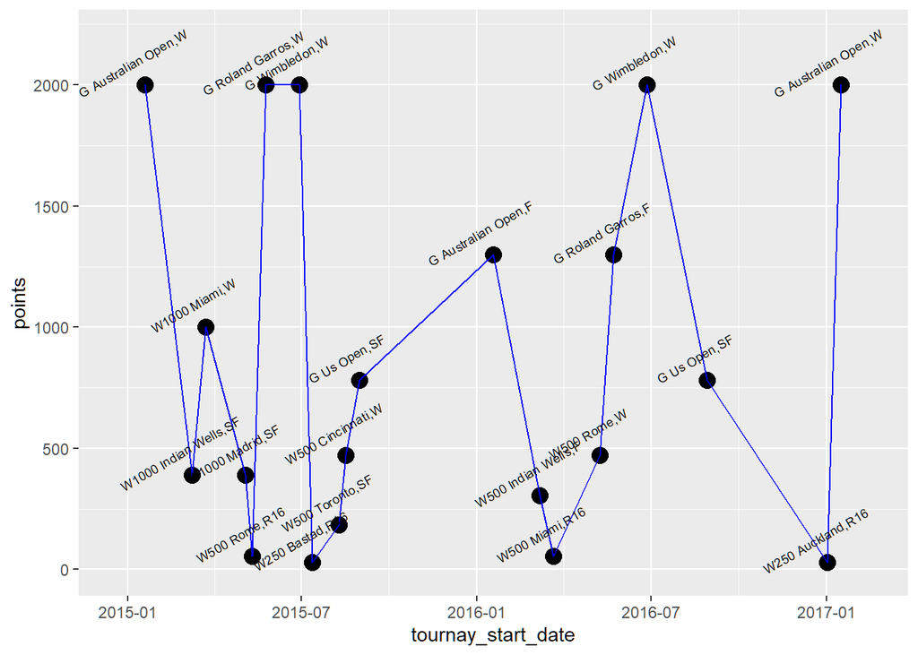

```r
Q15 %>% ggplot(aes(tourney_start_date,points,
               label = paste(tourney_name,round_ordered,sep = ","))) +
        geom_point(size = 4) +
        geom_line(color = "Blue") +
        geom_text(color = "black",angle=30,vjust = -2 ,size=2.5) +
        xlab("tournay_start_date")+ylab("points")+
        scale_x_date(expand = expansion(add = c(70, 70)))+ylim(0,2200)
```